# Test a Perceptual Phenomenon

### Analyzing the Stroop Effect

Perform the analysis in the space below. Remember to follow [the instructions](https://docs.google.com/document/d/1-OkpZLjG_kX9J6LIQ5IltsqMzVWjh36QpnP2RYpVdPU/pub?embedded=True) and review the [project rubric](https://review.udacity.com/#!/rubrics/71/view) before submitting. Once you've completed the analysis and write-up, download this file as a PDF or HTML file, upload that PDF/HTML into the workspace here (click on the orange Jupyter icon in the upper left then Upload), then use the Submit Project button at the bottom of this page. This will create a zip file containing both this .ipynb doc and the PDF/HTML doc that will be submitted for your project.

(1) What is the independent variable? What is the dependent variable?

*The dependent variable for the Stroop test is the difference in times reading the words of the first congruent and the second incongruent word sets. An independent variable for the Stroop test would be the reaction time of the test candidates.*

(2) What is an appropriate set of hypotheses for this task? Specify your null and alternative hypotheses, and clearly define any notation used. Justify your choices.

The set of hypotheses for this test would be  
Null hypothesis $H_0: t_1 = t_2$  
Alternative $H_A: t_1 < t_2$  
with $t_1$ and $t_2$ being the times to read the first and second word set. The Null hypothesis is what the scientists want to reject and as they expect a difference in reading time the null is that the reading times are the same.

(3) Report some descriptive statistics regarding this dataset. Include at least one measure of central tendency and at least one measure of variability. The name of the data file is 'stroopdata.csv'.

```python
# Perform the analysis here
import pandas as pd
import matplotlib.pyplot as plt
%matplotlib inline
import numpy as np
import scipy.stats as stats


df = pd.read_csv('stroopdata.csv')
df.describe()
```

|  | Congruent | Incongruent |
| --- | --- | --- |
| count | 24.000000 | 24.000000 |
| mean | 14.051125 | 22.015917 |
| std | 3.559358 | 4.797057 |
| min | 8.630000 | 15.687000 |
| 25% | 11.895250 | 18.716750 |
| 50% | 14.356500 | 21.017500 |
| 75% | 16.200750 | 24.051500 |
| max | 22.328000 | 35.255000 |

*The dataset to analyse constists of the results of 24 Stroop tests showing the time to read the first word set (congruent) and the second word set (incongruent). The mean of $t_1$ is 14.05 s with a standard deviation of 3.56 s and the mean of $t_2$ is 22.02 s with a standard deviation of 4.80 s.*

(4) Provide one or two visualizations that show the distribution of the sample data. Write one or two sentences noting what you observe about the plot or plots.

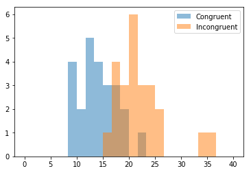

```python
# Build the visualizations here
bins = np.linspace(0, 40, 25)

plt.hist(df['Congruent'], bins, alpha=0.5, label='Congruent')
plt.hist(df['Incongruent'], bins, alpha=0.5, label='Incongruent')
plt.legend(loc='upper right')
plt.show()
```

(5) Now, perform the statistical test and report your results. What is your confidence level or Type I error associated with your test? What is your conclusion regarding the hypotheses you set up? Did the results match up with your expectations? **Hint:** Think about what is being measured on each individual, and what statistic best captures how an individual reacts in each environment.

```python
# Perform the statistical test here
stats.ttest_rel(df['Congruent'], df['Incongruent'])
```

```
Ttest_relResult(statistic=-8.020706944109957, pvalue=4.1030005857111781e-08)
```

Now will be tested whether the difference in reading times is statistically significant. I chose a relative t-test to perform this test, as this test will compare the two outcomes of the tests for the same set of test candidates.  
To reject the Null hypothesis with a 95% confidence limit the calculated p-value has to be lower than 0.025. Here a very small p-value of $4.10 \cdot 10^{⁻8}$ was calculated, thus we can reject the Null hypothesis and state that within 95% confidence the test time of the incongruent test is significant different from the test time for the congruent test and people tend to take longer to read incongruent colored color names.

(6) Optional: What do you think is responsible for the effects observed? Can you think of an alternative or similar task that would result in a similar effect? Some research about the problem will be helpful for thinking about these two questions!

*I personally think that it takes longer to read incongruent colored color names as the human brain is trained to process written words in terms of reading the letters instead of naming the colors of the letters. So when naming the color of letters you kind of have to "remind" your brain each time to not process the letters in the usual reading manner. I would expect a similar effect when you would ask someone to read a short text and then ask him how many times a specific word appeared in the text. He would have to go through the text again in his memory and then count the words actively as his brain only processed the text in the usual manner to read it and not to count words. The Stroop Effect [Wikipedia page](https://en.wikipedia.org/wiki/Stroop_effect) names Automaticity of word understanding due to habitual reading as opposed to color naming, Processing speed differences of words and colors in the brain and selective attention as the brain is thought to need more attention to recognize a color compared to word encoding.*

*A similar task is the Numerical Stroop, which involes comparing digits of different numerical values and physical sizes. Comparing incongruent digits, where the numerical value does not correpond how big or small the digit is written is slower than comparing digits in congruent trials. A similar effect is the [Simon effect](https://en.wikipedia.org/wiki/Simon_effect), naming the phenomenon that participants in front of a test monitor with to answer buttons tend to press the buttons faster when the stimulus on the screen is on the same side as the button.*